# Reproducible Research: Peer Assessment 1

Tim Harig

August 18, 2017

## Loading and preprocessing the data

The data set has been provided for this exercise. A copy is made that is then modified for analysis. Columns added are used in later steps of the analysis.

```r
####  Load data and pre-processing  ####
setwd("~/R_Files/DS5_Proj01")
##  Load the preprocessed data.
activityData <- read.csv("activity.csv")  ##  read data

##  create a duplicate data set for analytic process modifications
proc_AD <- activityData

proc_AD$dateNum <- as.numeric(proc_AD$date)  ##  add column expressing date factors as numeric
proc_AD$dayOfWeek <- weekdays(as.Date(proc_AD$date))  ##  add column for day of week
####  ####
```

## What is mean total number of steps taken per day?

In addition to the mean, we calculate and present the median and total values for steps per day. The Total steps per day are plotted in a histogram. A table is displayed with comparisons of mean, median and total values for each day of the study.

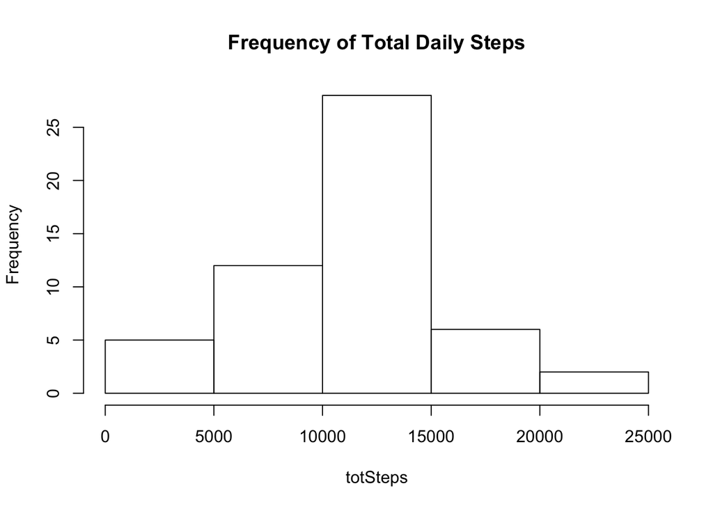

```r
####  What is the mean total number of steps taken each day?  ####
##    create vectors for daily mean, median and total number of steps
meanSteps <- numeric(0)
medSteps <- numeric(0)
totSteps <- numeric(0)
dayDate <- numeric(0)

##    for each of all 61 days of the study calculate mean, median and total steps
for(i in 1:61) {
        meanSteps[i] <- mean(proc_AD$steps[proc_AD$dateNum == i], na.rm = TRUE)
        medSteps[i] <- median(proc_AD$steps[proc_AD$dateNum == i], na.rm = TRUE)
        totSteps[i] <- sum(proc_AD$steps[proc_AD$dateNum == i])
        suppressWarnings(dayDate[i] <- as.character(proc_AD$date[proc_AD$dateNum == i]))
        ##  Note: warnings are given due to mis-match in data size with these variables.
        ##  warnings are suppressed to improve report clarity. This does not affect the analysis.
}

##    Make histogram of total steps taken each day
hist(totSteps, main = "Frequency of Total Daily Steps")
```

```r
##  Calculate and report the mean and median of the total number of steps taken per day
dfMeanMedTotDay <- data.frame(Date=dayDate, "Mean Daily Steps"=meanSteps,
                              "Median Daily Steps"=medSteps, "Total Daily Steps"=totSteps)
dfMeanMedTotDay
```

```
##          Date Mean.Daily.Steps Median.Daily.Steps Total.Daily.Steps
## 1  2012-10-01              NaN                 NA                NA
## 2  2012-10-02        0.4375000                  0               126
## 3  2012-10-03       39.4166667                  0             11352
## 4  2012-10-04       42.0694444                  0             12116
## 5  2012-10-05       46.1597222                  0             13294
## 6  2012-10-06       53.5416667                  0             15420
## 7  2012-10-07       38.2465278                  0             11015
## 8  2012-10-08              NaN                 NA                NA
## 9  2012-10-09       44.4826389                  0             12811
## 10 2012-10-10       34.3750000                  0              9900
## 11 2012-10-11       35.7777778                  0             10304
## 12 2012-10-12       60.3541667                  0             17382
## 13 2012-10-13       43.1458333                  0             12426
## 14 2012-10-14       52.4236111                  0             15098
```

[output cut: 47 more lines]

```r
####  ####
```

## Check anomalous data: all median values are zero (for days with data)!

The data set was analyzed to confirm that all days had fewer intervals with non-zero data than half the total number of intervals. This results in the median values of zero for all days (with data).

```r
####  Where data available, all daily median values are zero!  ####
##  this happens if number of values greater than zero is less than half the total measurements.
##  Is this true for all days?
dailyZero <- numeric(0)
for(i in 1:61){  ##  find total number of zero measurements for each day
         dailyZero[i] <- sum(proc_AD$isZero[proc_AD$dateNum == i])
}
##  how many have non-zero value measurements less than the half the total?
sum(dailyZero<145, na.rm = TRUE)
```

```
## [1] 61
```

```r
####  Median values for all days with values are correctly reported as zero.  ####
```

## What is the average daily activity pattern?

The average number of steps taken in each five minute interval is computed and plotted. The maximum avareage steps for an interval is found along with the its time interval.

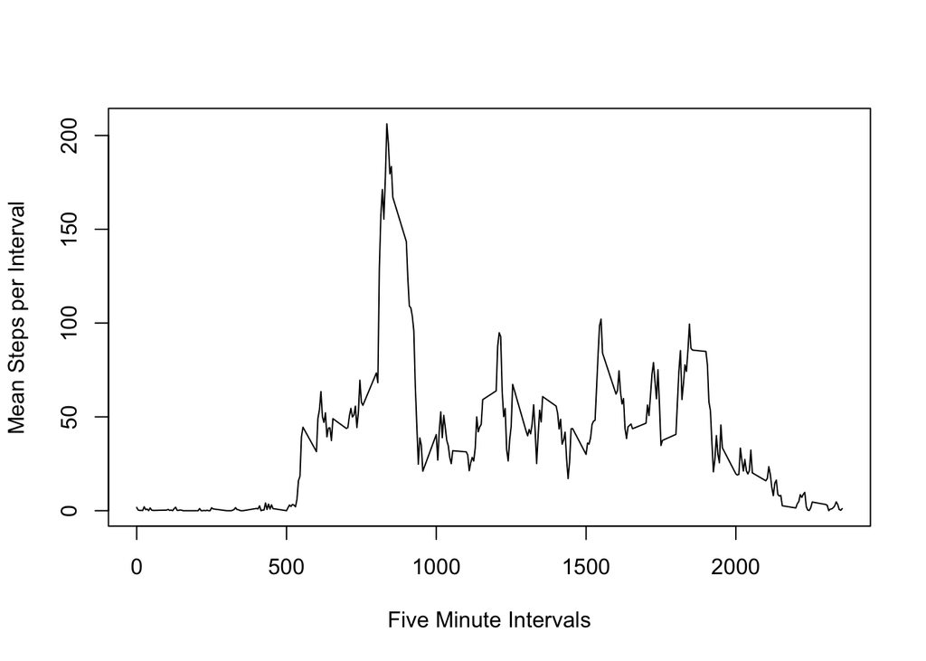

```r
####    What is the average daily activity pattern?  ####
##      create variables for daily activity statistics
fiveMinIntervals <- numeric(0)
hourIntervals <- numeric(0)
intervalIndex <- numeric(0)
fiveMinAvg <- numeric(0)

##  create an index for the daily sequence of the 'interval' variable
for (i in 1:12) {  ##  basic five minute intervals (0 to 55 for each day)
        fiveMinIntervals[i] <- (i-1)*5
}
for(j in 1:24){ ##  create hour component (0, 100, 200, ... 2300)
        hourIntervals[j] <- (j-1) * 100
}
for(k in 1:24){  ## create index in time format: hhmm
        intervalIndex <- c(intervalIndex, fiveMinIntervals + hourIntervals[k])
}

##  compute the average steps for each five minute period for each day
for(ii in intervalIndex){
        fiveMinAvg <-  c(fiveMinAvg, mean(proc_AD$steps[proc_AD$interval == ii], na.rm = TRUE), proc_AD$typeOfDay)
}

plot(intervalIndex, fiveMinAvg, type = "l",
     xlab = "Five Minute Intervals", ylab = "Mean Steps per Interval")
```

```r
which.max(fiveMinAvg)  ##  max. average steps in five minute interval
```

```
## [1] 104
```

```r
intervalIndex[which.max(fiveMinAvg)]  ##  time of day for max average steps, read as: hhmm
```

```
## [1] 835
```

```r
####  ####
```

## Imputing missing values

Missing values will be replaced by the average value for the appropriate five minute interval. We first check to find which columns have missing data. ‘Steps’ is the only column that has missing data.

Calculation of data statistics (mean, median and total for each day) are repeated for the modified data set. Median values are now reported for the days that previously had no data. Mean and total values are higher due to the addition of values that had previously not been part of the analysis.

```r
####  Imputting Missing Values  ####
##  number of missing values in data set (Note: 'steps' is the only column with missing values.)
sum(is.na(proc_AD$steps))
```

```
## [1] 2304
```

```r
sum(is.na(proc_AD$interval))
```

```
## [1] 0
```

```r
sum(is.na(proc_AD$date))
```

```
## [1] 0
```

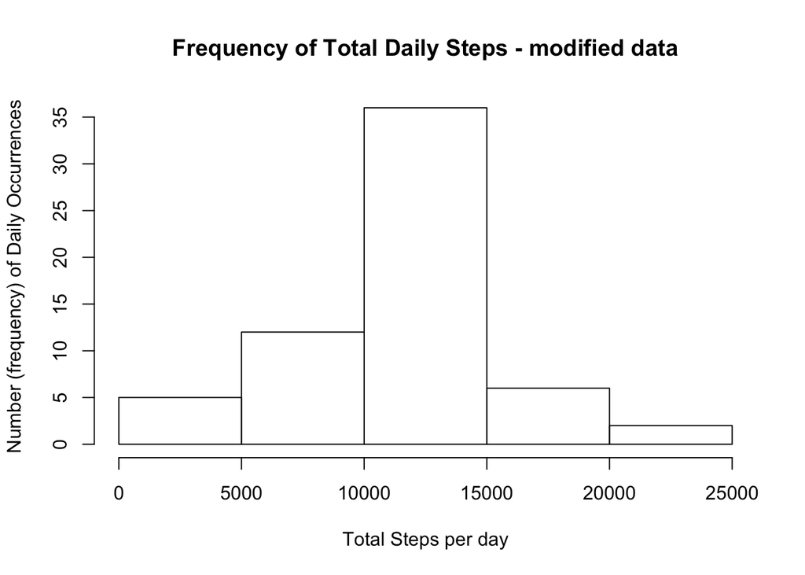

```r
##  create a missing value flag
proc_AD$missingValue <- is.na(proc_AD$steps)

##  replace missing values with average for appropriate five minute interval
proc_AD$steps <- replace(proc_AD$steps, proc_AD$missingValue, fiveMinAvg)

##    as before, create vectors for daily mean, median and total number of steps using imputted data
mod_meanSteps <- numeric(0)
mod_medSteps <- numeric(0)
mod_totSteps <- numeric(0)

##    for each of all 61 days, using imputted data, calculate mean, median and total steps
for(i in 1:61) {
        mod_meanSteps[i] <- mean(proc_AD$steps[proc_AD$dateNum == i], na.rm = TRUE)
        mod_medSteps[i] <- median(proc_AD$steps[proc_AD$dateNum == i], na.rm = TRUE)
        mod_totSteps[i] <- sum(proc_AD$steps[proc_AD$dateNum == i])
}

##    Make histogram of total steps taken each day
hist(mod_totSteps, main = "Frequency of Total Daily Steps - modified data",
     xlab = "Total Steps per day", ylab = "Number (frequency) of Daily Occurrences")
```

```r
##  Calculate and report the mean and median of the total number of steps taken per day
dfmod_MeanMedTotDay <- data.frame(Date=dayDate, "Mean daily Steps"=mod_meanSteps,
                                  "Median Daily Steps"=mod_medSteps, "Total Daily Steps"=mod_totSteps)
dfmod_MeanMedTotDay
```

```
##          Date Mean.daily.Steps Median.Daily.Steps Total.Daily.Steps
## 1  2012-10-01       37.3825996           34.11321          10766.19
## 2  2012-10-02        0.4375000            0.00000            126.00
## 3  2012-10-03       39.4166667            0.00000          11352.00
## 4  2012-10-04       42.0694444            0.00000          12116.00
## 5  2012-10-05       46.1597222            0.00000          13294.00
## 6  2012-10-06       53.5416667            0.00000          15420.00
## 7  2012-10-07       38.2465278            0.00000          11015.00
## 8  2012-10-08       37.3825996           34.11321          10766.19
## 9  2012-10-09       44.4826389            0.00000          12811.00
## 10 2012-10-10       34.3750000            0.00000           9900.00
## 11 2012-10-11       35.7777778            0.00000          10304.00
## 12 2012-10-12       60.3541667            0.00000          17382.00
## 13 2012-10-13       43.1458333            0.00000          12426.00
## 14 2012-10-14       52.4236111            0.00000          15098.00
```

[output cut: 47 more lines]

```r
####  ####
```

## Are there differences in activity patterns between weekdays and weekends?

The plot comparing weekday to weekend average interval activity clearly shows that weekdays have a spike of activity early (around 8:35), while weekends show a failry steady level of activity during the day. Inactive sleep periods are apparent in both cases.

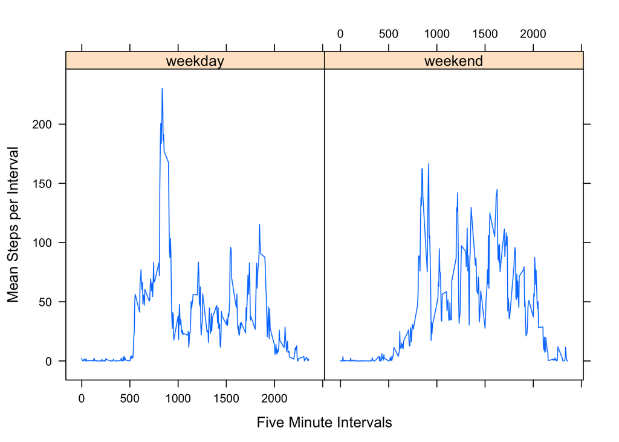

```r
####  Differences in Activity Patterns Between Weekdays and Weekends  ####
##  create a factor variable for 'weekday' and 'weekend' and assign to data
proc_AD$typeOfDay <- factor(c("weekday", "weekend"))
proc_AD$typeOfDay <- "weekday"  ##  initialize all to 'weekday'
##  change Sat. and Sun. factors
proc_AD$typeOfDay[proc_AD$dayOfWeek == "Sunday"] <- "weekend"
proc_AD$typeOfDay[proc_AD$dayOfWeek == "Saturday"] <- "weekend"

##  find five minute interval averages for weekday and weekend days
##  first, seperate weekday and weekend data
proc_AD_wd <- subset(proc_AD, proc_AD$typeOfDay == "weekday", select = c(steps, interval, typeOfDay))
proc_AD_we <- subset(proc_AD, proc_AD$typeOfDay == "weekend", select = c(steps, interval, typeOfDay))
##  as before, compute the average steps for each five minute period for each type of day
fiveMinAvg_wd <- numeric(0)
fiveMinAvg_we <- numeric(0)
for(ii in intervalIndex){
        fiveMinAvg_wd <-  c(fiveMinAvg_wd, mean(proc_AD_wd$steps[proc_AD_wd$interval == ii], na.rm = TRUE))
        fiveMinAvg_we <-  c(fiveMinAvg_we, mean(proc_AD_we$steps[proc_AD_we$interval == ii], na.rm = TRUE))
}
##  combine data needed to create graph in data frames
fiveMinAvg_wd <- cbind.data.frame(intervalIndex, stepsAvg=fiveMinAvg_wd, typeOfDay="weekday")
fiveMinAvg_we <- cbind.data.frame(intervalIndex, stepsAvg=fiveMinAvg_we, typeOfDay="weekend")
fiveMinAvg_typeDay <- rbind(fiveMinAvg_wd, fiveMinAvg_we)

##  compare graphs of weekday and weekend averages
library("lattice", lib.loc="/Library/Frameworks/R.framework/Versions/3.3/Resources/library")
xyplot(stepsAvg ~ intervalIndex | typeOfDay, data = fiveMinAvg_typeDay, type="l",
       xlab = "Five Minute Intervals", ylab = "Mean Steps per Interval")
```

```r
############################################################################################
```

End of report.